# Analysis of MPG vs Transmission type

Alper Halbutogullari, November 10, 2015

## Executive summary

We are trying to answer the following questions:

*“Is an automatic or manual transmission better for MPG”*  
*“Quantify the MPG difference between automatic and manual transmissions”*

Based on the given (mtcars) data set, all else being equal, cars with manual transmissions are more efficient than the ones with automatic transmissions. The difference is, on average, 7.24 mpg. This value has a 95% confidence interval of [3.21 , 11.28], in other words we are 95% confident that the savings is 7.24 $\pm$ 4.03 mpg.

## Analysis

### Summary of the data

The data was extracted from the 1974 Motor Trend US magazine, and comprises fuel consumption and other aspects of automobile design and performance for 32 automobiles (1973–74 models). We will only be using the mpg & am (transmission type, 0 = Automatic, 1 = Manual) features.

### Initial Exploration

If we visualize how mpg changes with transmission type (see Figure 1 in Appendix), then we see that there is clearly a difference (~7 mpg). However we need to check the significance of this hypothesis.

Although transmission type is a categorical variable, because it has only two values, we can treat it as numerical. So let’s check the correlation between mpg and the transmission type:

```r
cor.test(mtcars$mpg, mtcars$am)
```

```
##
##  Pearson's product-moment correlation
##
## data:  mtcars$mpg and mtcars$am
## t = 4.1061, df = 30, p-value = 0.000285
## alternative hypothesis: true correlation is not equal to 0
## 95 percent confidence interval:
##  0.3175583 0.7844520
## sample estimates:
##       cor
## 0.5998324
```

Based on the p value (0.000285) from the above result, we can confidently say that there is a direct correlation.

So, let’s try linear regression to model the relation between MPG and the transmission type:

```r
fit <- lm(mpg ~ am, data = mtcars)
summary(fit)
```

```
##
## Call:
## lm(formula = mpg ~ am, data = mtcars)
##
## Residuals:
##     Min      1Q  Median      3Q     Max
## -9.3923 -3.0923 -0.2974  3.2439  9.5077
##
## Coefficients:
##             Estimate Std. Error t value Pr(>|t|)
## (Intercept)   17.147      1.125  15.247 1.13e-15 ***
## am             7.245      1.764   4.106 0.000285 ***
## ---
## Signif. codes:  0 '***' 0.001 '**' 0.01 '*' 0.05 '.' 0.1 ' ' 1
##
## Residual standard error: 4.902 on 30 degrees of freedom
## Multiple R-squared:  0.3598, Adjusted R-squared:  0.3385
## F-statistic: 16.86 on 1 and 30 DF,  p-value: 0.000285
```

This model tells us that we can formulate the mpg-am relation by the following formula (see Figure 2 for more details) :

```
mpg = 17.147 + 7.245 * am
```

7.245, the coefficient of am in the above formula, is the mpg difference between cars with automatic and manual transmissions (with automatic transmissions consuming more gallons of gas per mile).

Let’s also check the significance of this with a t-test:

```r
t.test(mpg ~ am, data=mtcars)
```

```
##
##  Welch Two Sample t-test
##
## data:  mpg by am
## t = -3.7671, df = 18.332, p-value = 0.001374
## alternative hypothesis: true difference in means is not equal to 0
## 95 percent confidence interval:
##  -11.280194  -3.209684
## sample estimates:
## mean in group 0 mean in group 1
##        17.14737        24.39231
```

## Conclusion.

As seen from both of the results above, cars with manual transmission provide a savings of, on average, 7.24494 mpg over cars with automatic transmission, with a 95% confidence interval of [3.21 , 11.28].

## Appendix

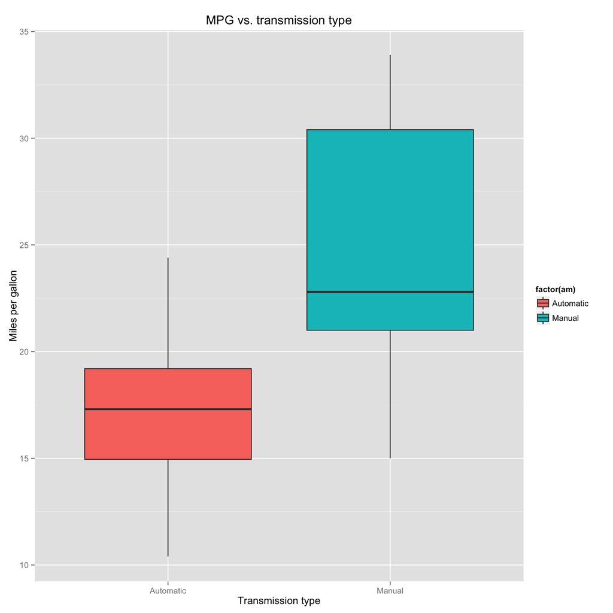

Figure 1: How mpg changes with transmission type

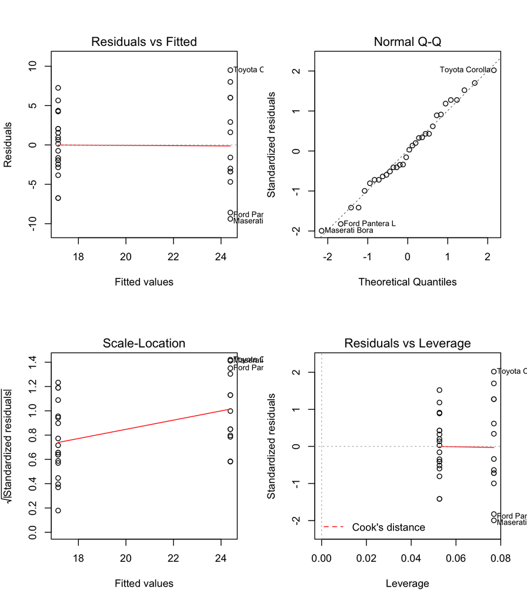

Figure 2: Details of model “fit”